# Questions and answers

Michael Franke & Michael Henry Tessler

# session 1

## question 1

[Q] With respect to prior beliefs about $\theta$ - when we assign $\theta$ the value 0.5 : does it mean that we believe that the coin is fair / or neither fair nor biased?

[A] If we assume that $\theta = 0.5$, i.e., we believe that $P(\theta = 0.5) = 1$, we believe that the coin is perfectly fair, so that each outcome has exactly the same probability. A belief that the coin is might be fair or biased would assign some probability (mass) to the possibility that $\theta = 0.5$ but also probability to other values for $\theta$.

examples of probabilistic beliefs

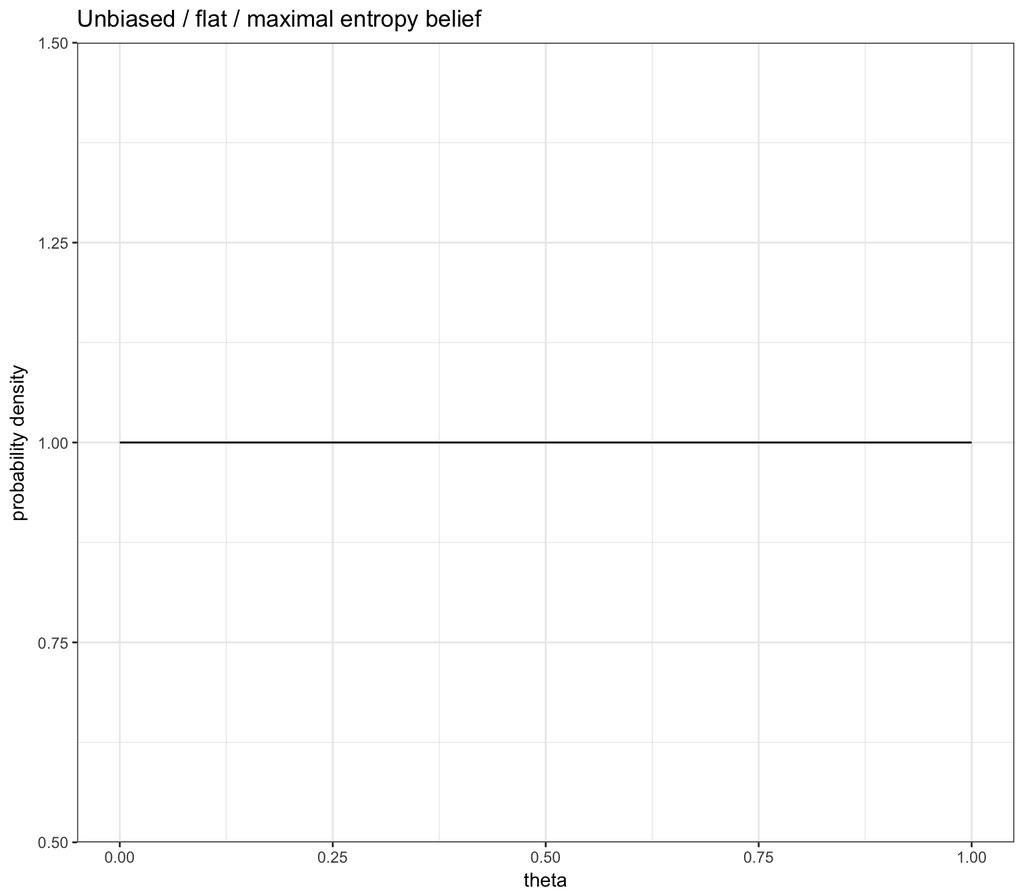

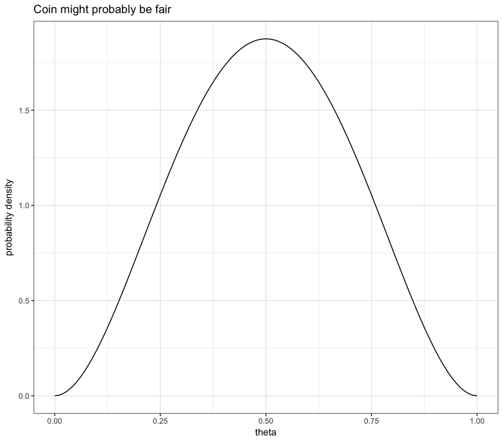

examples of probabilistic beliefs

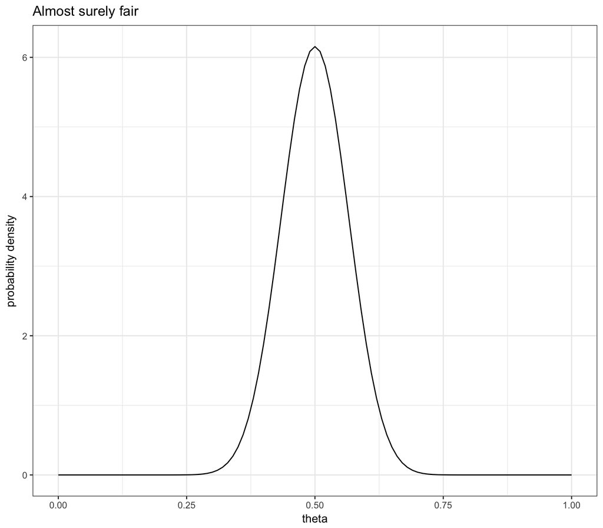

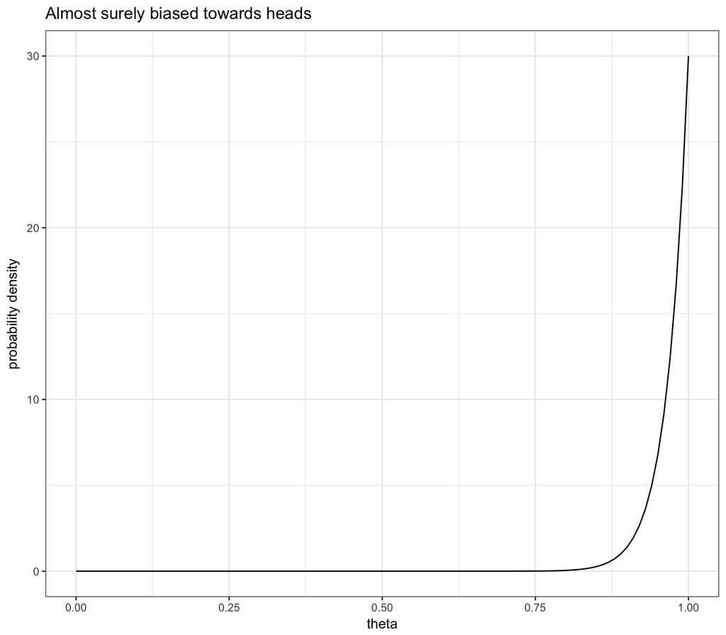

examples of probabilistic beliefs

[figure not shown]

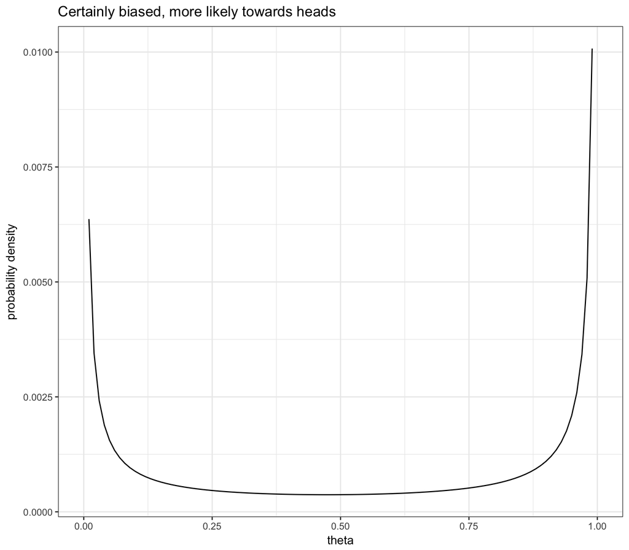

## question 2

[Q] What do you mean when you say that Bayes theorem enables to reverse conditional probabilities?

$$\underbrace{P(\theta \, | \, D)}_{posterior} \propto \underbrace{P(D \, | \, \theta)}_{likelihood} \ \underbrace{P(\theta)}_{prior}$$
We have a “feedforward theory” of how a given $\theta$ makes some $D$ more or less likely; this is the likelihood function. We use Bayes theorem to reverse this relationship, in order to infer the “likely underlying causes” from the observable data.

## question 3

[Q] How does the marginal likelihood enters the equation? What does it denote?

[A] We specified Bayes rule for data inference as:

$$\underbrace{P(\theta \, | \, D)}_{posterior} \propto \underbrace{P(D \, | \, \theta)}_{likelihood} \ \underbrace{P(\theta)}_{prior}$$
This is shorthand notation for:

$$P(\theta \, | \, D) = \frac{P(D \, | \, \theta) \ P(\theta)}{\underbrace{\int P(D \mid \theta') \ P(\theta') \text{d}\theta'}_{=P(D)}}$$

where the normalizing constant $\int P(D \mid \theta') \ P(\theta') \text{d}\theta'$ is also called the marginal likelihood. It denotes the *a priori* likelihood of observing data $D$ (obtained by marginalizing over all possible parameter values).

## question 4

[Q] You talked about misconstrued interpretations of the $p$-value and said it can not be taken to be the likelihood that the null-hypothesis is true given your data. Did I misunderstand something? I’ve always thought of this as the definition for the p-Value.

[A] You are in excuisite company. Even many statistics lecturers misinterpret $p$-values (see [this paper](https://www.metheval.uni-jena.de/lehre/0405-ws/evaluationuebung/haller.pdf), for instance). Here is a simple intuitive argument that shows that $p$-values do *not* represent the probability of the null-hypothesis given the data.

No matter what you believe about my coin, as long as you do not already believe with absolute certainty that it is fair, would you be absolutely certain that it is if I flip it twice and we observe one outcome of heads? – I definitely would not yet rule out that it might not be a value different from $\theta = 0.5$, but the associated $p$-value is 1. (Interestingly, it is also 1 for the null-hypotheses $\theta = 0.49$ and $\theta = 0.51$. So if $p$-values gave you the likelihood of the null hypothesis, you should place probability 1 beliefs on mutually incompatible world states.)

# session 2

[Q] While studying generative processes it was mentioned that the sample size plays a critical role in the outcome of the final distribution. So how do we know whether a given sample set is enough? Especially, since the process of calculating the marginal likelihood is also a computationally intensive process is there an objective way to calculate the sample size ?

[A] First of all, the computation of the marginal likelihood would only matter if we wanted to approximate a posterior/conditional probability distribution. But in fact, the inference algorithms used (such as MCMC, rejection etc.) are designed in such a way that they do not need to calculate the marginal likelihood.

So, how do you know that your sample size gives you an approximation that is good enough? – You might never know for sure. But suppose you take 1 million samples. Then you compare the results after 900,000 with those after 1 million. If you see no substantial difference (e.g., measured in terms a divergence between probability distributions), you probably do not need to collect more than 1 million samples.

Wait! How do I know that this one set of samples is representative? – You might never know for sure. That’s why (for some inference algorithms (like MCMC)) we would usually take at least two independent sets of samples and again quantify their divergence as a diagnostic.

# session 3

[Q] How is the posterior distribution different from the posterior predictive distribution? It seems as if one is dependent on $\theta$ while the other isn’t. How can I understand this more concretely?

[A] The posterior distribution is a distribution over latent parameter values:

$$\underbrace{P(\theta \, | \, D)}_{posterior} \propto \underbrace{P(D \, | \, \theta)}_{likelihood} \ \underbrace{P(\theta)}_{prior}$$

So, the posterior distribution gives degrees of belief as to how likely a particular parameter value/hypothesis is, given the data.

In contrast, predictive distributions are distributions over possible observations:

$$P(D \mid D') = \int \underbrace{P(\theta \mid D')}_{\text{posterior}} \ \underbrace{P(D \mid \theta)}_{\text{likelihood}} \ \text{d}\theta$$

So, the posterior predictive distribution gives degrees of belief as to how likely a particular possible future observation is, given your posterior distribution over parameter values.

# session 4

## question 1

[Q] Is the functional form of posterior (say Gaussian) the same as that of the prior (say Gaussian)? Can we have a scenario where the prior was a Gaussian, but posterior turned out to be mixture of two Gaussian?

[A] In general, there is no guarantee that the form of the posterior is the same as that of the prior. However, sometimes, when we fix a particular likelihood function $L$, we can prove that when the prior is given as a distribution of type $X$, the posterior will also be a distribution of type $X$. in That case we say that $X$ is a conjugate prior for likelihood function $L$.

For example, the Beta distribution is a conjugate prior for the binomial distribution.

## question 2

[Q] If we assign zero probability to an event in prior, is there any possibility of having a non-zero probability for that event in the posterior?

[A] No. Bayes rule helps you readjust positive probabilities. As soon as you (foolishly) rule out an event completely *a priori*, you cannot “update it back in”.

## question 3

[Q] I have noticed that some RSA-models involve both «log» and «exp» in a soft-max version of the Bayes rule, but some models involve only «exp». What is the reason for that?

[A] Actually, these superficially similar model equations represent two rather difference ideas about what communication is about. Details can be found in the paper by [Qing & Franke (2015)](http://www.home.uni-osnabrueck.de/michfranke/Papers/QingFranke_2013_Variations_on_Bayes.pdf), including a Bayesian model comparison of these variants.

The $\log$ comes from information theory and, using it, we implement the idea that speakers want to minimize the distance between their own belief and that of the literal interpreter. With the $\log$ we get a belief-based utility.

Without the $\log$, we rather get an action-based utility as is common in, say, game theory. The speaker wants to maximize the chance that the listener selects the correct referent.

## question 4

[Q] The RSA-model is based on parameters (c, alpha). Does it mean that this model can explain any data through the manipulation of parameters? What evidence could falsify this model?

[A] We have seen data in class that “falsified” this model.

## question 5

[Q] Are there different types of cost functions ? How do we decide which cost function to use and when ?

[A] When you design your probabilistic model, you are the boss. You should use a cost function (or whatever other ingredient) that makes most conceptual sense to you. This is your theory. It is what you will have to defend.

When defending a particular choice, you can appeal to conceptual coherence, common sense, mathematical elegance, prior use in the literature, …